# US Natality Data: Causal Inference Case Study

Dataset Preparation

```r
knitr::opts_chunk$set(echo=TRUE, warning=FALSE, message=FALSE, comment=NA)

library(dplyr)     # tables
library(readr)     # reading
library(stringr)   # strings
library(purrr)     # fp
library(tidyr)     # remove_na
library(forcats)   # factor recode
library(janitor)   # remove_constant columns
library(corrplot)  # plot correlation matrix
#library(sufrep)   # sufficient representations
source("make_encoder.R") # modified sufficient representations

rm(list = ls())    # reset environment
source("utils.R")  # import helpers

# The seed is set before every randomized operation throughout so results
# are consistent when rerunning cells.
```

This notebook preprocesses data from the Vital Statistics Natality Birth Data. It first takes a working subset of the raw source CSV and parses the columns to their correct types (binary, numeric, ordered or unordered factor).

A new variable `smoking` is created with three levels, `none, light, heavy`. Three datasets are created.

1. Binary treatment `smoking_light`, this dataset only contains light and non-smokers.
2. Binary treatment `smoking_heavy`, this dataset only contains heavy and non-smokers.
3. Continuous treatment `cigar` (number of cigarettes smoked per day).

We filter all of these to a subset where our treatment and outcome variable `dbirwt` (birth weight) are non-missing since they cannot be for the purposes of our analysis, and then sample 100,000 records for analysis.

# Subset and preprocess data

```r
# In theory variable, currently only 2002 preprocessing implemented
year <- 2002

# Data size for analysis: 100,000
data_size <- as.integer(1e5)
```

To begin with we sample a subset of birth records uniformly at random. We sample more than the desired `data_size` so that there is enough data remaining after preprocessing and filtering. Sampling at this stage speeds up the following steps since the full dataset is quite large (1.8GB).

```r
subset <- TRUE

subset_fname <- paste0("data/subset_rds/natl", year, ".rds")

if (subset) {
  raw_fname <- paste0("data/raw_csv/natl", year, ".csv")
  set.seed(74)
  # select a random sample
  natl_raw <-
    read_csv(raw_fname, col_types = cols(.default = col_character())) %>%
    sample_n(2 * data_size) # larger sample so dropping some data leaves enough

  write_rds(natl_raw, subset_fname, compress = "gz")
}
```

Convert text csv to factors using preprocessing code from `preprocess_natl2002.R`. This mostly just fixes the factor levels to match those described in the data [documentation](https://data.nber.org/natality/2002/natl2002.pdf). It does make some changes to two variables as noted at the top of the preprocessing code.

Also filter to singleton births and add treatment variables.

```r
preprocess <- TRUE

preprocessed_fname <- paste0("data/preprocessed_rds/natl", year, ".rds")

if (preprocess) {
  source(paste0("preprocess/preprocess_natl", year, ".R"))
  natl_full <- read_rds(subset_fname) %>%

    # preprocess natl, fix types / levels and modify variables (monpre, dmar)
    preprocess_natl() %>%

    # filter to singleton births to maintain independent samples
    filter(dplural == 1) %>%

    # add NEW variables
    mutate(
      smoking = case_when(
        cigar ==  0 ~ "none",
        cigar <  10 ~ "light",
        cigar >= 10 ~ "heavy") %>%
        factor(levels = c("none", "light", "heavy")),
      smoking_heavy = smoking == "heavy",
      smoking_light = smoking == "light")

  write_rds(natl_full, preprocessed_fname, compress = "gz")
}

natl_full <- read_rds(preprocessed_fname)
```

# Prepare Data

Here we select our covariates to control for confounding. Since the original natality dataset contains multiple codings for the same features, here we select a single coding per variable of interest.

```r
# Select variables to consider as covariates to control for confounding
covariates <- list(
  general = c("restatus"),  # Resident Status
  occur =   c("stnatexp",   # Expanded State of Occurrence
              "cntocpop"),  # Population Size of County of Occurrence
  resid =   c("stresexp",   # Expanded State of Residence
              "cntrspop",   # Population Size of County of Residence
              "citrspop",   # Population Size of City of Residence
              "metrores",   # Metropolitan County of Residence
              "cntrspop"),  # Population Size of County of Residence
  mother =  c("dmage",      # Age of Mother
              "ormoth",     # Hispanic Origin of Mother
              "mrace",      # Race of Mother
              "dmeduc",     # Education of Mother
              "dmar",       # Marital status MODIFIED
              "mplbir",     # Place of Birth of Mother
              "adequacy",   # Adequacy Of Care Recode (Kessner Index)
              "nlbnl",      # Number of Live Births Now Living
              "nlbnd",      # Number of Live Births Now Dead
              "noterm",     # Number of Other Terminations
              "dlivord",    # Detail Live Birth Order
              "monpre",     # Detail Month of Pregnancy Prenatal Care Began MODIFIED
              "nprevis"),   # Total Number of Prenatal Visits
  father =  c("dfage",      # Age of Father
              "orfath",     # Hispanic Origin of Father
              "frace"),     # Race of Father
  child =   c("dgestat",    # Gestation - Detail in Weeks
              "csex"),      # Sex
  med_rsk = c("anemia",     # Anemia (Hct.<30/Hgb.<10)
              "cardiac",    # Cardiac disease
              "lung",       # Acute or chronic lung disease
              "diabetes",   # Diabetes
              "herpes",     # Genital herpes
              "hydra",      # Hydramnios/Oligohydramnios
              "hemo",       # Hemoglobinopathy
              "chyper",     # Hypertension - chronic
              "phyper",     # Hypertension - pregnancy-associated
              "eclamp",     # Eclampsia
              "incervix",   # Incompetent cervix
              "pre4000",    # Previous infant 4000+ grams
              "preterm",    # Previous preterm or small-for-gestational-age infant
              "renal",      # Renal disease
              "rh",         # Rh sensitization
              "uterine",    # Uterine bleeding
              "othermr"),   # Other Medical Risk Factors
  oth_rsk = c("drink",      # Average Number of Drinks Per Week
              "wtgain"))    # Weight Gain
```

Datasets are created with the following treatments.

1. Binary treatment `smoking_light`, this dataset only contains light and non-smokers.
2. Binary treatment `smoking_heavy`, this dataset only contains heavy and non-smokers.
3. Continuous treatment `cigar` (number of cigarettes smoked per day).

```r
# Covariate names
Xnames <- unlist(covariates)
names(Xnames) <- NULL # otherwise select renames columns below

# Prepare datasets
set.seed(50)
natl <- list()

# treatment types (we replicate the encoding for each one)
treatments <- c("smoking_light", "smoking_heavy", "cigar")

natl[["smoking_light"]] <- natl_full %>%
  filter(!smoking_heavy) %>% # remove heavy smokers
  select(all_of(c(Xnames, "dbirwt", "smoking_light"))) %>% # select variables
  drop_na(all_of(c("dbirwt", "smoking_light"))) %>% # Y, W are not NA
  sample_n(data_size) # select num. of samples for analysis

natl[["smoking_heavy"]] <- natl_full %>%
  filter(!smoking_light) %>% # remove light smokers
  select(all_of(c(Xnames, "dbirwt", "smoking_heavy"))) %>% # select variables
  drop_na(all_of(c("dbirwt", "smoking_heavy"))) %>% # Y, W are not NA
  sample_n(data_size) # select num. of samples for analysis

natl[["cigar"]] <- natl_full %>%
  select(all_of(c(Xnames, "dbirwt", "cigar"))) %>% # select variables
  drop_na(all_of(c("dbirwt", "cigar"))) %>% # Y, W are not NA
  sample_n(data_size) # select num. of samples for analysis

# save model data
for (treat in treatments) {
  natl_fname <- paste0("models/natl/natl", year, ".", treat, ".rds")
  write_rds(natl[[treat]], natl_fname, compress = "gz")
}
```

The top 7 missing variables are mother’s place of birth, population size of county of occurrence, fathers race, origin, and age, and the mother’s vaginal herpes and uterine bleeding status. All other variables are missing in less than 6% of samples. (The continuous treatment data is shown in this example, but the two binary treatment datasets are similar.)

```r
natl$cigar %>%
  summarise(across(.fns = function (x) sum(is.na(x)) / length(x))) %>%
  pivot_longer(cols = everything()) %>%
  arrange(desc(value)) %>%
  rename(fracNA = value) %>%
  head(10)
```

| name | fracNA |
| --- | --- |
| mplbir | 0.29135 |
| cntocpop | 0.21480 |
| frace | 0.14881 |
| orfath | 0.14880 |
| dfage | 0.13983 |
| herpes | 0.11732 |
| uterine | 0.11732 |
| wtgain | 0.05938 |
| adequacy | 0.03113 |
| nprevis | 0.02381 |

Note that missing values in this dataset can be due to a variety of factors. A large proportion of missingness is explained by regional variations in reporting, and this and other factors lead many variable pairs to have a high missingness correlation.

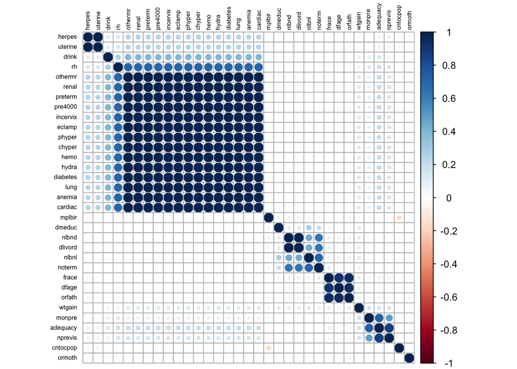

```r
set.seed(245)
M <- natl$cigar %>%
  sample_n(1000) %>%
  summarise(across(.fns = is.na)) %>%
  remove_constant() %>%
  cor()

# plot NA fraction correlations
corrplot(M, method="circle", order="hclust", tl.col = "black", tl.cex = 0.5)
```

# Factor Representation / Group Encoding

Our models will require exclusively numeric-valued inputs, and we therefore need to encode group-valued variables as numeric. First we split the data into variables that can be directly converted to numbers (i.e.numeric values, ordered factors, and binary factors) from those that require group encoding.

```r
natl_num <- list() # numeric variables
natl_grp <- list() # group variables

for (treat in treatments) {
  # numeric and binary values
  natl_num_bin <- natl[[treat]] %>%
    select_if(function (col) (is.numeric(col) || is.logical(col))) %>%
    transmute(across(everything(), ~ as.numeric(.)))

  # ordered factors
  natl_ord <- natl[[treat]] %>%
    select_if(function (col) (is.factor(col) && is.ordered(col))) %>%
    # preserve numeric coding of factor levels instead of level index
    transmute(across(everything(), ~ as.numeric(as.character(.))))

  # combine ordered types
  natl_num[[treat]] <- bind_cols(natl_num_bin, natl_ord)

  # unordered factors that need encoding
  natl_grp[[treat]] <- natl[[treat]] %>%
    select(-one_of(names(natl_num[[treat]]))) # drop numeric cols
}
```

Note that simply using one-hot encoding would massively expands the number of variables since some of our group variables have many levels (i.e. 50+ states).

```r
natl_grp_nlevels <- list()

for (treat in treatments) {
  natl_grp_nlevels[[treat]] <- sapply(natl_grp[[treat]], nlevels)
}

natl_grp_nlevels$cigar
```

```
restatus stnatexp stresexp   ormoth    mrace   mplbir   orfath    frace
       4       57       61        6       16       56        6       16
    csex
       2
```

Most of the one-hot dimensions come from `stnatexp`, `stresexp`, and `mplbir`, all of which are geographic variables. The race variables `mrace` and `frace` also contribute many group levels / dimensions. For these variables specifically, it would be helpful to use alternate encodings.

```r
natl_grp_encoding_types <- list()

for (treat in treatments) {
  natl_grp_encoding_types[[treat]] <- natl_grp_nlevels[[treat]] %>%
    map(function(nlevels) {
      # use sparse low rank where one-hot would be "too" high dimensional
      if (nlevels < 10) "one_hot" else "sparse_low_rank"
    })
}
```

We then generate encoders of these types. Note that our modification of the `sufrep` code currently encodes the NAs in the factor G as a separate level. An alternate approach would be to leave NA values NA in all their dimensions. It also drops NA values in X in the means encoding to which SPCA is applied.

```r
# Make sure we have our modified make_encoder that works with NA covariates in X
source("make_encoder.R")
natl_grp_encoders <- list()

for (treat in treatments) {
  natl_grp_encoders[[treat]] <-
    map2(natl_grp_encoding_types[[treat]], natl_grp[[treat]],
         function(encoding, G) {
           make_encoder(encoding,
                        X = as.matrix(select(natl_num[[treat]],
                                             -all_of(c("dbirwt", treat)))),
                        G = G, num_components = 6)
         })
}
```

Generate the corresponding encodings on our data.

```r
natl_grp_encodings <- list()

for (treat in treatments) {
  natl_grp_encodings[[treat]] <- natl_grp_encoders[[treat]] %>%
    map2(natl_grp[[treat]], # apply encoder function .x
         ~ as.data.frame(
           .x(X = as.matrix(select(natl_num[[treat]], -all_of(c("dbirwt", treat)))),
              G = .y))) %>%
    map2_dfc(names(natl_grp[[treat]]), # rename columns "varname.dim"
             ~ rename_with(.x, function (x) paste(.y, 1:length(.x), sep=".")))
}
```

Finally, recombine with the numeric variables to give our data matrix.

```r
natl_rep <- list()

for (treat in treatments) {
  # combine numeric and encoded group variables
  natl_rep[[treat]] <- bind_cols(natl_num[[treat]], natl_grp_encodings[[treat]])

  # save model data
  natl_rep_fname <- paste0("models/natl_rep/natl", year, ".", treat, ".rds")
  write_rds(natl_rep[[treat]], natl_rep_fname, compress = "gz")
}
```

```r
head(natl_rep$cigar, 10)
```

| metrores | dmage | dmeduc | dmar | nlbnl | nlbnd | noterm | dlivord | monpre | nprevis | dfage | dgestat | anemia | cardiac | lung | diabetes | herpes | hydra | hemo | chyper | phyper | eclamp | incervix | pre4000 | preterm | renal | rh | uterine | othermr | drink | … |
| --- | --- | --- | --- | --- | --- | --- | --- | --- | --- | --- | --- | --- | --- | --- | --- | --- | --- | --- | --- | --- | --- | --- | --- | --- | --- | --- | --- | --- | --- | --- |
| 1 | 24 | 12 | 0 | 2 | 0 | 0 | 3 | 8 | 14 | 19 | 42 | 0 | 0 | 0 | 0 | 0 | 0 | 0 | 0 | 0 | 0 | 0 | 0 | 0 | 0 | 0 | 0 | 0 | 0 | … |
| 1 | 26 | 12 | 1 | 3 | 0 | 1 | 4 | 9 | 20 | 29 | 37 | 0 | 0 | 0 | 0 | 0 | 0 | 0 | 0 | 0 | 0 | 0 | 0 | 0 | 0 | 0 | 0 | 0 | 0 | … |
| 1 | 27 | 17 | 1 | 0 | 0 | 0 | 1 | 8 | 16 | 27 | 43 | 0 | 0 | 0 | 0 | 0 | 0 | 0 | 0 | 0 | 0 | 0 | 0 | 0 | 0 | 0 | 0 | 0 | 0 | … |
| 1 | 30 | 12 | 0 | 1 | 0 | 0 | 2 | 9 | 11 | 42 | 39 | 0 | 0 | 0 | 0 | 0 | 0 | 0 | 0 | 0 | 0 | 0 | 0 | 0 | 0 | 1 | 0 | 0 | 0 | … |
| 1 | 22 | 12 | 1 | 1 | 0 | 0 | 2 | 8 | 14 | 24 | 37 | 0 | 0 | 0 | 0 | 0 | 0 | 0 | 0 | 0 | 0 | 0 | 0 | 0 | 0 | 0 | 0 | 0 | 0 | … |
| 1 | 26 | 16 | 1 | 0 | 0 | 0 | 1 | 7 | 9 | 28 | 41 | 0 | 0 | 0 | 0 | 0 | 0 | 0 | 0 | 0 | 0 | 0 | 0 | 0 | 0 | 0 | 0 | 1 | 0 | … |
| 0 | 17 | 12 | 0 | 0 | 0 | 0 | 1 | 4 | 7 | 17 | 40 | 0 | 0 | 0 | 0 | 0 | 0 | 0 | 0 | 0 | 0 | 0 | 0 | 0 | 0 | 0 | 0 | 0 | 0 | … |
| 0 | 22 | 13 | 1 | 2 | 0 | 0 | 3 | 6 | 13 | 26 | 40 | 0 | 0 | 0 | 0 | 0 | 0 | 0 | 0 | 0 | 0 | 0 | 0 | 0 | 0 | 0 | 0 | 0 | 0 | … |
| 0 | 27 | 12 | 1 | 2 | 0 | 1 | 3 | 8 | 17 | 28 | 38 | 0 | 0 | 0 | 0 | 0 | 0 | 0 | 0 | 0 | 0 | 0 | 0 | 0 | 0 | 0 | 0 | 0 | 0 | … |
| 1 | 27 | 14 | 1 | 0 | 0 | 2 | 1 | 9 | 14 | 30 | 39 | 0 | 0 | 0 | 0 | 0 | 0 | 0 | 0 | 0 | 0 | 0 | 0 | 0 | 0 | 0 | 0 | 0 | 0 | … |